# Act Report

## By Ariyo Joseph

[figure not shown]

`WeRateDogs` is a Twitter account that rates people's dogs with a humorous comment about the dog. The account was started in 2015 by college student Matt Nelson, and has received international media attention both for its popularity and for the attention drawn to social media copyright law when it was suspended by Twitter for breaking these aforementioned laws

These ratings almost always have a denominator of 10. The numerators, though? Almost always greater than 10. 11/10, 12/10, 13/10 etc? Why? Because "they're good dogs Brent. WeRateDogs has over 4 million followers and has received international media coverage.

So what to do with these ratings? Which is the most popular dog? Is there a relationship between Retweets, Favorites and Ratings? The timeseries of the data in respect to the retweets and favorites ratings? The distribution of the retweet counts and favorite counts? where most of the data came from? I have wrangled the WeRateDogs twitter and have analysed it to get answers to the questions. Python has helped me with some cool visualizations for my analysis.

#### Most popular breeds

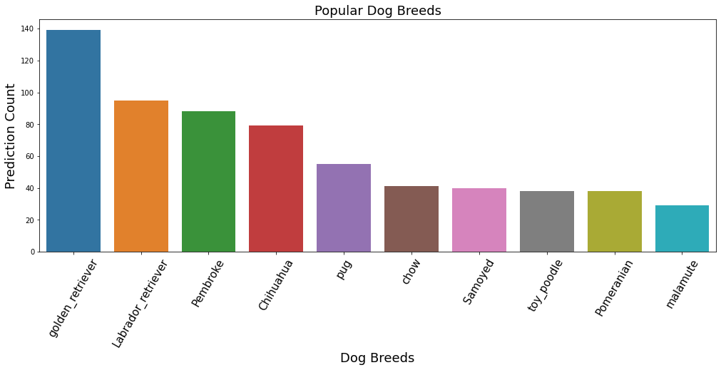

- The Golden retriever is the most predicted dog breed. It is expected. My personal favorite is Labrador_retriever. These dogs have most tweets on them, which has led them on our popular list.

#### Distribution of retweet counts

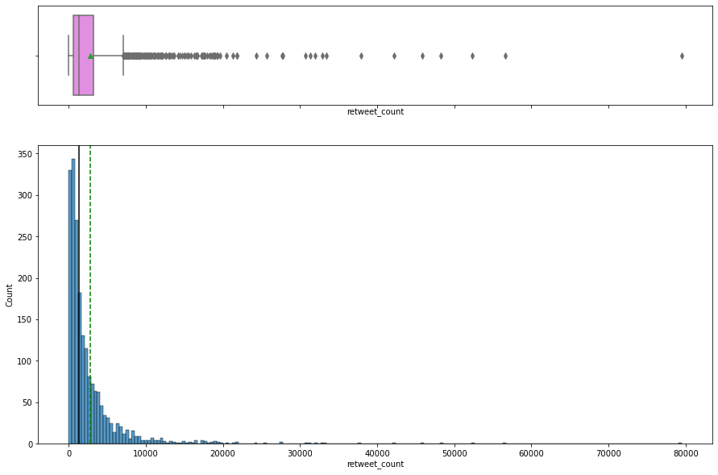

- The retweet count is right skewed which means the average retweet count is more than the median.
- The box plot shows that there is a lot of outliers.

#### Distribution favorite counts

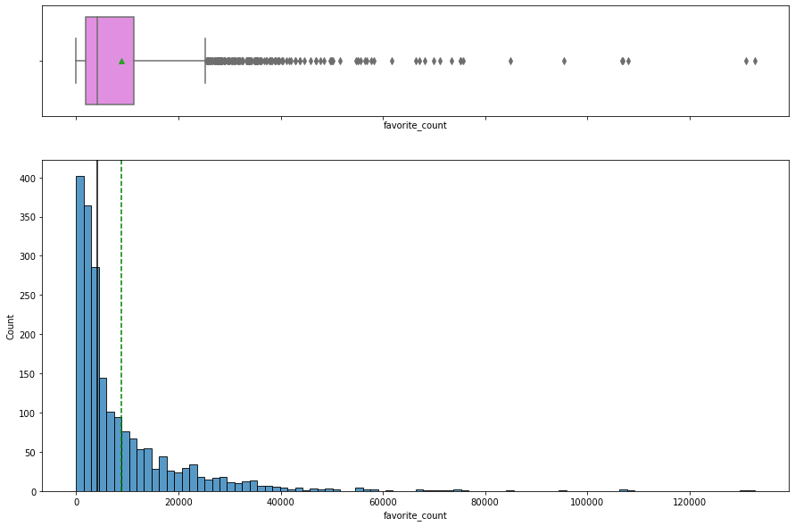

- The favorite count is right skewed which means the average retweet count is more than the median.
- The box plot shows that there is a lot of outliers.

#### Source of data

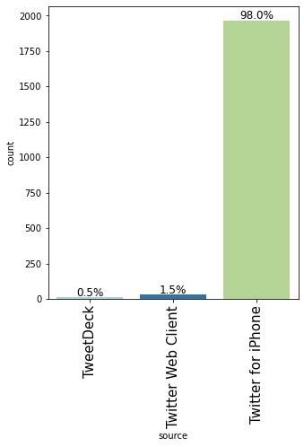

- Data extracted are mainly from users that have an iphone followed by the web.

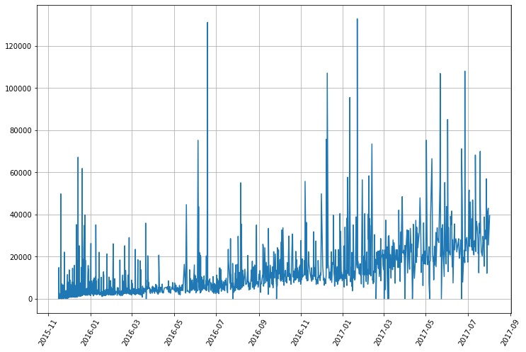

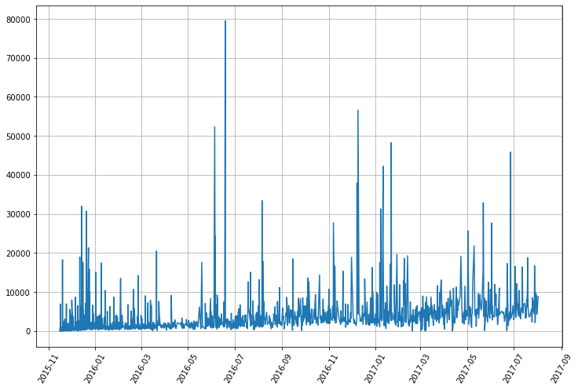